# My TikTok Habits

## How well does TikTok know me?

A moving, exaggerated thinking emoji

Welcome to this journey surrounding my personal TikTok habits which I have recorded through 5-minute timed scroll sessions. Each session captures a brief picture of my scrolling insight, from the content that was chosen to be pushed out to me, to whether I was mindlessly scrolling or genuinely watching my feed. Together, the three visualisations of my data below explore whether the type of content on my feed, the time of day I was scrolling, and my overall engagement level can expose meaningful patterns of how I consume TikTok.

## I hate ads!

On average, I watched roughly 13.5 videos per scroll session.

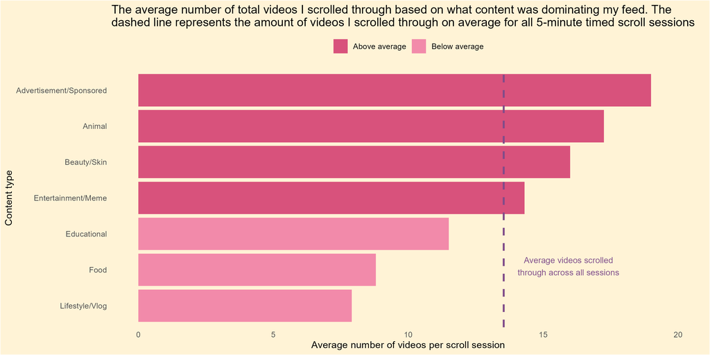

A horizontal bar chart showing the average number of videos scrolled per 5-minute session for seven content types. Bars are coloured dark pink for above average and light pink for below average. A dashed vertical line on the plot represents the overall session average of approximately 13.5 videos. Advertisement/Sponsored content has the highest average at 19 videos, followed by Animal, Beauty/Skin, and Entertainment/Meme being all above average. Educational, Food, and Lifestyle/Vlog fall below average, with Lifestyle/Vlog the lowest at approximately 8 videos.

The content types with the most videos scrolled (above average) tend to be where engagement was mostly skipped, and there’s no surprise that advertisements and sponsored posts are at the very top of this. Safe to say I am **not** interested in promotional content. On the other hand, lifestyle/vlog content seems to capture my full attention being at the very bottom of scrolls per session, which checks out as I find that content rather relatable and fun. This plot essentially suggests that more scrolling does not reflect more enjoyment of content.

## TikTok can be my teacher

Although I use TikTok to decompress, It seems as though I still like to get something out of my scrolls, and this may consist of valuable information aka educational information!

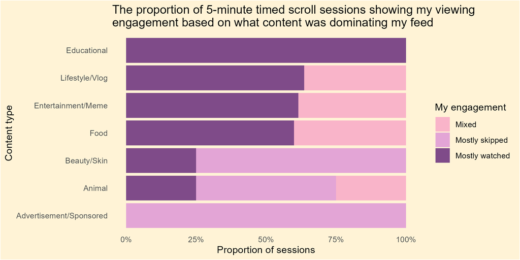

A horizontal 100% stacked bar chart showing the proportion of 5-minute timed scroll sessions that were mostly watched, mixed, or mostly skipped for each of seven content types, sorted from highest to lowest proportion of mostly watched sessions. Educational content has the highest engagement with 100% of sessions mostly watched. Lifestyle/Vlog, Entertainment/Meme and Food content follow. In contrast, Beauty/Skin and Animal content show a great shift, with around 75% and 50% of sessions being mostly skipped. Advertisement/Sponsored content has 100% of sessions mostly skipped.

This pattern in proportion of sessions mostly watched, mostly skipped and mixed for each content type, illustrates that content the TikTok algorithm actively pushed towards me being a female consumer, such as advertisements or beauty content, was actually consistently avoided for, while more ‘self-selected’ content such as educational and lifestyle videos were watched more deliberately. Similarly again, my engagement with advertisements are next to none as indicated by having 100% of scroll sessions that were dominated by Advertisement/Sponsored content being mostly skipped.

## Get to know me TikTok

My guilty pleasure is a little doomscroll before bed, but wouldn’t it be nice to have all the intriguing videos lined up and ready to go!

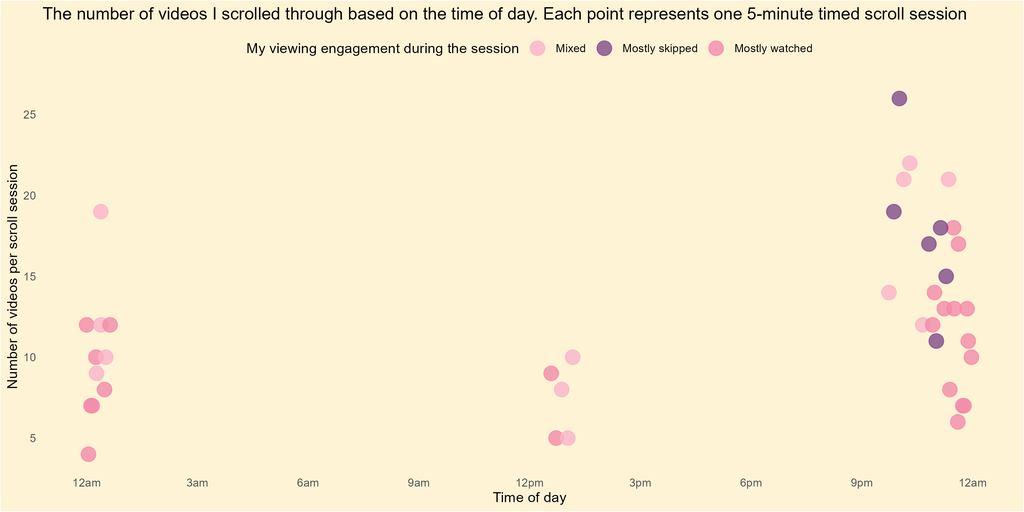

A scatter plot showing the number of videos scrolled through per 5-minute session on the y-axis against the time of day on the x-axis. Each point represents one session coloured by engagement type, light pink for mixed, dark purple for mostly skipped, and medium pink for mostly watched. The sessions cluster into three main time periods, late at night between 9pm to 12am, midnight between 12am and 1am and around midday between 12pm and 1pm. The cluster between 9pm and 12am is the largest and most varied, containing the highest video counts including one mostly skipped session reaching 26 videos at approximately 10pm, this cluster is the only cluster to contain the mostly skipped engagement type sessions. The midnight to 1am and midday clusters are smaller and have lower video counts per session.

But evidently TikTok sadly doesn’t work this way. The only points on the plot showing mostly skipped scroll sessions are all situated near the beginning of my entire doomscroll. This suggests that when I first open TikTok at night, I tend to have to filter out unwanted media by swiping away, but luckily the TikTok algorithm catches on relatively quick and I see an increase in mostly watched sessions afterwards (continuing my doomscroll to my heart’s content).

## To conclude

Across all three visualisations, a significant pattern emerges where the content TikTok chooses to push onto my feed does not always reflect what I genuinely enjoy watching. The data suggests while yes, TikTok does keep me scrolling, it does not always succeed in serving me effective content that I actually want to watch and a lot of time may be wasted filtering out unwanted content from my feed.

[figure not shown]

A very distressed, sad or dissaponted emoji